# Anemia en infantes y mujeres

## 8. Variables aleatorias continuas

### 8.1 Hemoglobina ajustada en función de la latitud ($g/dl$)

```
  [1] 12.3 12.6 14.4 13.3 15.0 13.0 14.2 14.3 12.0 13.5  8.1 14.1 11.6 12.2 10.9
 [16] 13.4 14.5 13.9 14.6 12.5 11.8 12.7 13.8 12.1 11.9 13.6 13.1 14.0 13.2 11.5
 [31] 12.9 10.3  8.3 11.2 11.0 13.7 14.7 12.8 12.4 11.1  8.9 11.3  9.9 15.2 10.6
 [46] 10.8  9.1 10.5 10.7 10.1 11.7  9.0 10.2 11.4  9.7  9.4  9.3 14.8  7.7 15.1
 [61] 15.3 15.4  9.8  9.6 10.4  8.4  7.5 14.9 15.5 16.5  9.2 15.8  8.5 15.6 15.7
 [76]  8.8  9.5  7.4  8.7  7.9  8.0  5.5  6.5 16.1 16.0 16.4 15.9  7.0 10.0  8.2
 [91]  5.8  7.2  5.9 18.1  7.8  7.6 17.0  6.7  6.8  8.6 16.7 16.2 16.6  6.1  6.4
[106] 18.6  6.6 16.3 18.3 18.9  7.3  5.2 17.7  7.1  6.3  6.9 17.2  5.7 17.5 17.1
[121] 17.8 18.4  6.2 16.8  3.3 16.9  4.1  4.6  6.0  3.5  5.0  4.3
```

La continuidad de esta variable se relaciona con la naturaleza de la medición. En un contexto práctico, los niveles de hemoglobina pueden variar de manera suave y gradual, y no se limitan a valores discretos específicos. La posibilidad de tener un número infinito de valores en cualquier rango dado hace que la hemoglobina sea una variable continua.

- **Validamos las propiedades de esperanza, varianza, desviación estándar y coeficiente de variación**

```
Esperanza (media): 12.68532
```

```
Varianza: 1.613424
```

```
Desviación estándar: 1.270206
```

```
Coeficiente de variación: 0.100132
```

- **Identificamos la distribución**

**Primero**, generamos un histograma y un gráfico de densidad kernel para obtener una visión integral de la distribución de los datos y comprender mejor su comportamiento.

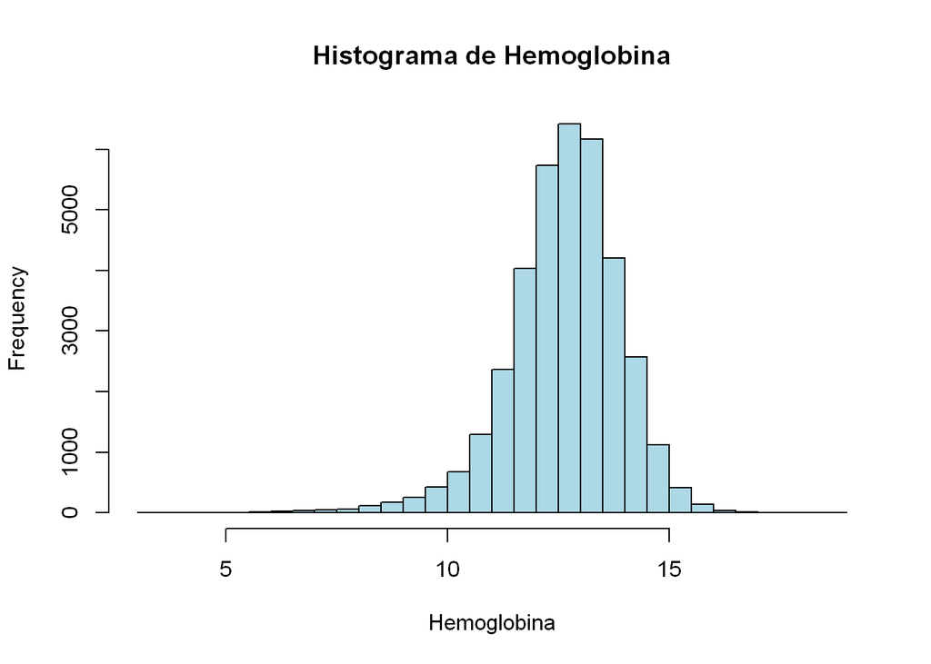

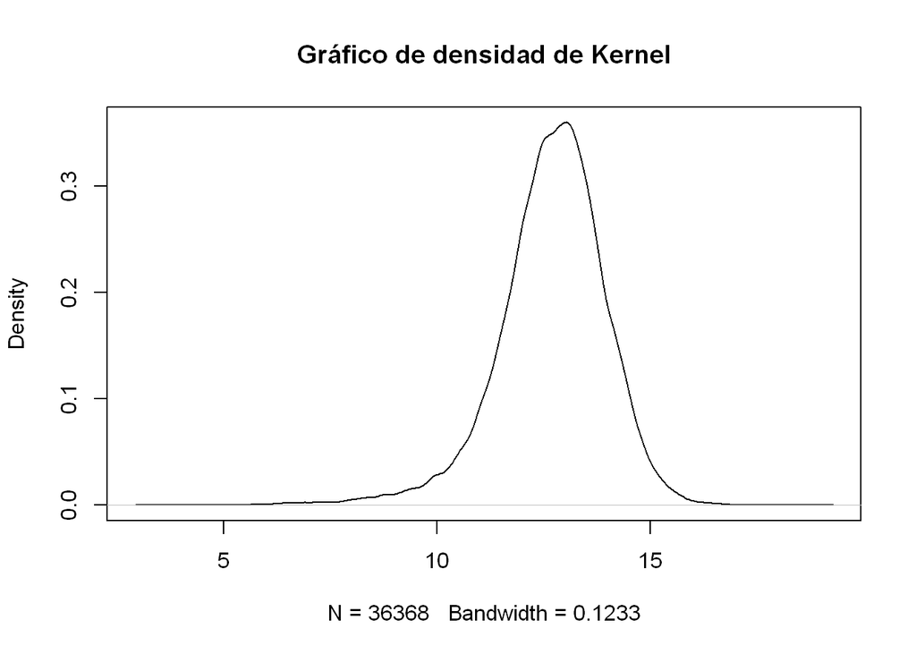

**Segundo**, utilizamos la biblioteca **`rriskDistributions`** para realizar ajustes de distribuciones continuas a los datos de la variable **`hemoglobina_ajustada_latitud`** almacenados en el vector **`x`**. Luego, visualizamos los datos utilizando la función **`View(x)`** y procedemos a realizar el ajuste con la función **`fit.cont(x)`**.

[output not shown]

[output not shown]

[output not shown]

[output not shown]

[output not shown]

[output not shown]

[output not shown]

[output not shown]

[output not shown]

[output not shown]

[output not shown]

[output not shown]

[output not shown]

[output not shown]

[output not shown]

[output not shown]

```
                  logL       AIC       BIC Chisq(value) Chisq(p) AD(value)
Normal       -60301.93 120607.85 120624.86      6521.16        0    207.40
Cauchy       -63650.12 127304.25 127321.25      7455.54        0    439.59
Logistic     -59114.62 118233.24 118250.24      1508.42        0     60.75
Exponential -128758.91 257519.82 257528.32    277332.86        0  13693.59
Chi-square   -93143.05  186288.1  186296.6     78517.47        0   7504.65
Uniform           NULL      NULL      NULL          Inf        0       Inf
Gamma        -61793.91 123591.82 123608.83     16452.41        0    382.36
Lognormal    -62772.61 125549.23 125566.23     25285.31        0    499.63
Weibull      -59594.86 119193.72 119210.72      1554.11        0       Inf
F           -172527.44 345058.88 345075.88   1018217.99        0  21057.38
Student     -201840.58 403683.16 403691.66   2323104.93        0  37284.61
               H(AD) KS(value)    H(KS)
Normal      rejected      0.06 rejected
Cauchy      rejected      0.08 rejected
Logistic    rejected      0.03 rejected
Exponential rejected      0.52 rejected
Chi-square      NULL      0.34 rejected
Uniform         NULL      0.11 rejected
Gamma       rejected      0.08 rejected
Lognormal   rejected      0.09 rejected
Weibull     rejected      0.05 rejected
F               NULL      0.67 rejected
Student         NULL      0.82 rejected
```

```
Chosen continuous distribution is: Normal (norm)
Fitted parameters are:
     mean        sd
12.685317  1.270189
```

- **Vamos a utilizar el modelo de distribución normal:**

$$X \sim N(\mu,\sigma^2
)$$

- **Definimos parámetros**

$\mu$ : Es el valor de la media de la variable.

$\sigma^2$ : Es el valor de la varianza de la variable.

Observemos una gráfica de distribución normal en torno a los parámetros descritos:

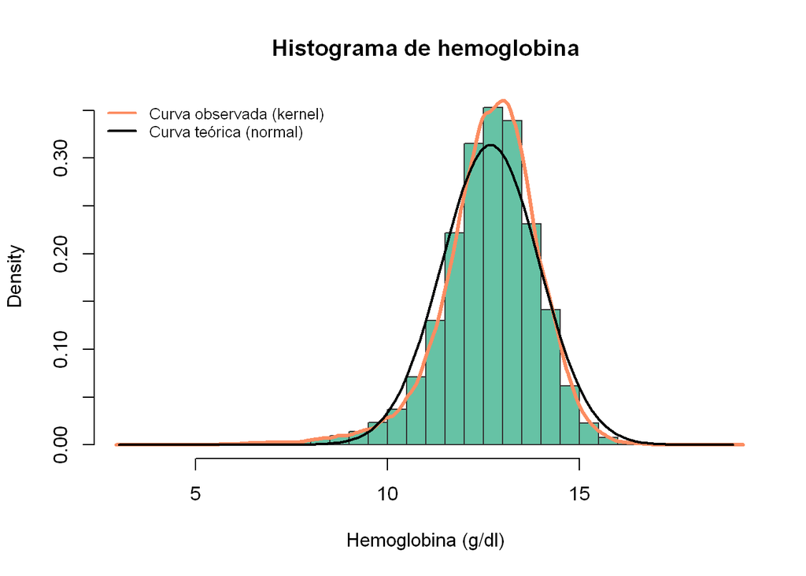

- **Definimos nuestra variable aleatoria continua**

**X**: Nivel de hemoglobina en $g/dl$ de una madre encuestada.

- **Experimento**

Probabilidad de que una madre tenga menos de 12 $g/dl$ hemoglobina.

$$P(X < 12)$$

```
[1] 0.2947574
```

La probabilidad de que una madre tenga 12 $g/dl$ o menos de hemoglobina, según el resultado proporcionado (0.2947574), indica que hay una probabilidad relativamente baja de que una madre seleccionada al azar tenga una concentración de hemoglobina de 12 $g/dl$ o inferior, según la distribución normal ajustada a los datos.

Escogimos ese rango de hemoglobina debido a que es el rango en el que empieza la anemia. Por lo tanto, esperamos que sea cercano a lo siguiente:

```
0.sin_anemia       1.leve   2.moderado      3.grave
       28165         7142          978           83
```

```
[1] 0.2255554
```

Los resultados se aproximan.

### 8.2 Peso ($kg$)

[output not shown]

[output cut: 60 more lines]

La naturaleza continua de la variable de peso se relaciona directamente con la forma en que se mide. En un contexto práctico, los valores de peso pueden variar de manera suave y gradual, extendiéndose a lo largo de un rango continuo. A diferencia de las medidas discretas, como contar el número de elementos, el peso tiene la capacidad de tomar un número infinito de valores en cualquier intervalo dado.

- **Validamos las propiedades de esperanza, varianza, desviación estándar y coeficiente de variación**

```
Esperanza (media): 62.72915
```

```
Varianza: 176.5763
```

```
Desviación estándar: 13.2882
```

```
Coeficiente de variación: 0.2118346
```

- **Identificamos la distribución**

**Primero**, generamos un histograma y un gráfico de densidad kernel para obtener una visión integral de la distribución de los datos y comprender mejor su comportamiento.

[figure not shown]

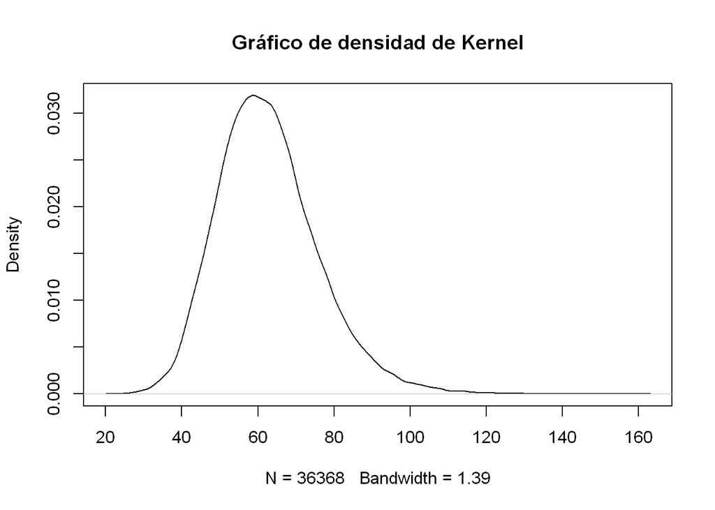

[output not shown]

[output not shown]

[output not shown]

[output not shown]

[output not shown]

[output not shown]

[output not shown]

[output not shown]

[output not shown]

[output not shown]

[output not shown]

[output not shown]

[output not shown]

[output not shown]

[output not shown]

[output not shown]

```
                  logL       AIC       BIC Chisq(value) Chisq(p) AD(value)
Normal      -145682.98 291369.96 291386.96      2812.19        0    153.71
Cauchy      -150765.04 301534.09 301551.09      9227.58        0    532.67
Logistic    -145308.34 290620.68 290637.68      1497.45        0     90.01
Exponential -186888.83 373779.66 373788.16    100648.47        0  10654.10
Chi-square  -145545.44 291092.89 291101.39      3653.23        0    212.57
Uniform           NULL      NULL      NULL          Inf        0       Inf
Gamma       -144578.42 289160.83 289177.84       389.43        0     17.56
Lognormal    -144464.1  288932.2 288949.21       184.92        0      4.41
Weibull     -147674.98 295353.95 295370.96      5996.56        0       Inf
F           -246643.07 493290.14 493307.14    680752.81        0  18742.19
Student     -273782.87 547567.74 547576.24   1475954.66        0  34826.38
               H(AD) KS(value)    H(KS)
Normal      rejected      0.04 rejected
Cauchy      rejected      0.09 rejected
Logistic    rejected      0.03 rejected
Exponential rejected      0.45 rejected
Chi-square      NULL      0.04 rejected
Uniform         NULL      0.09 rejected
Gamma       rejected      0.02 rejected
Lognormal   rejected      0.01 rejected
Weibull     rejected      0.07 rejected
F               NULL      0.65 rejected
Student         NULL      0.81 rejected
```

```
Chosen continuous distribution is: Normal (norm)
Fitted parameters are:
    mean       sd
62.72915 13.28802
```

- **Vamos a utilizar el modelo de distribución normal:**

$$X \sim N(\mu, \; \sigma^2 )$$

- **Definimos parámetros**

$\mu$ : Es el valor de la media de la variable.

$\sigma^2$ : Es el valor de la varianza de la variable.

Observemos una gráfica de distribución normal en torno a los parámetros descritos:

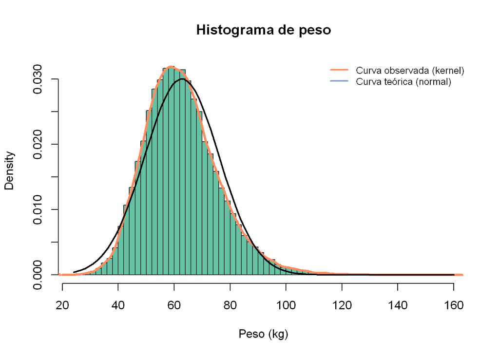

- **Definimos nuestra variable aleatoria continua**

$X$: Peso en $kg$ de una madre encuestada.

- **Experimento**

Probabilidad de que una madre pese más de 70 $kg$.

$$P(X > 70)$$

```
[1] 0.2921298
```

La probabilidad de que una madre pese más de 70 $kg$, según el resultado proporcionado (0.2921298), indica que hay una probabilidad relativamente baja de que una madre seleccionada al azar tenga un peso de más de 70 $kg$, según la distribución de la variable aleatoria continua ajustada a los datos.

## 9. Conclusiones

Con respecto al primer objetivo, podemos concluir lo siguiente:

- Los niños menores a 10 meses son más propensos a desarrollar cualquier tipo de anemia.
- Las mujeres menores de 20 años son más propensas a desarrollar anemia leve, mientras que las mayores de 30 suelen desarrollar anemia moderada o grave.

Con respecto al segundo objetivo, podemos concluir lo siguiente:

- Ucayali es la región con mayor incidencia de anemia moderada, superando a Lima a pesar de tener menos población.

Con respecto al tercer objetivo, podemos concluir lo siguiente:

- Los niños que viven en una residencia rural son más propensos a tener anemia moderada que los que viven en residencia urbana.